# Association between two independent nominal variables

Paul AMAT (https://amatpauldesign.github.io/)

2026-08-28

## 1 Context and objectives

> Is there an association between two nominal variables?

### 1.1 Research hypothesis

Mood (Happy vs. Sad) is associated with gender.

### 1.2 Statistical hypothesis

H0: Mood and gender are independent (no association).

H1: Mood and gender are associated.

## 2 Data preparation and exploration

### 2.1 Starting session

```r
set.seed(9043)
data <- data.frame(
  gender = rep(c("Man", "Woman"), each = 60),
  mood   = c(sample(c("Happy", "Sad"), 60, replace = TRUE, prob = c(0.40, 0.60)),
             sample(c("Happy", "Sad"), 60, replace = TRUE, prob = c(0.65, 0.35))),
  profil = sample(c("Athletic", "Dreamer", "Scientist"), 120, replace = TRUE)
)
```

### 2.2 Observed counts

```r
t <- table(data$mood, data$gender)
t
```

```
##
##         Man Woman
##   Happy  23    36
##   Sad    37    24
```

### 2.3 Visualize

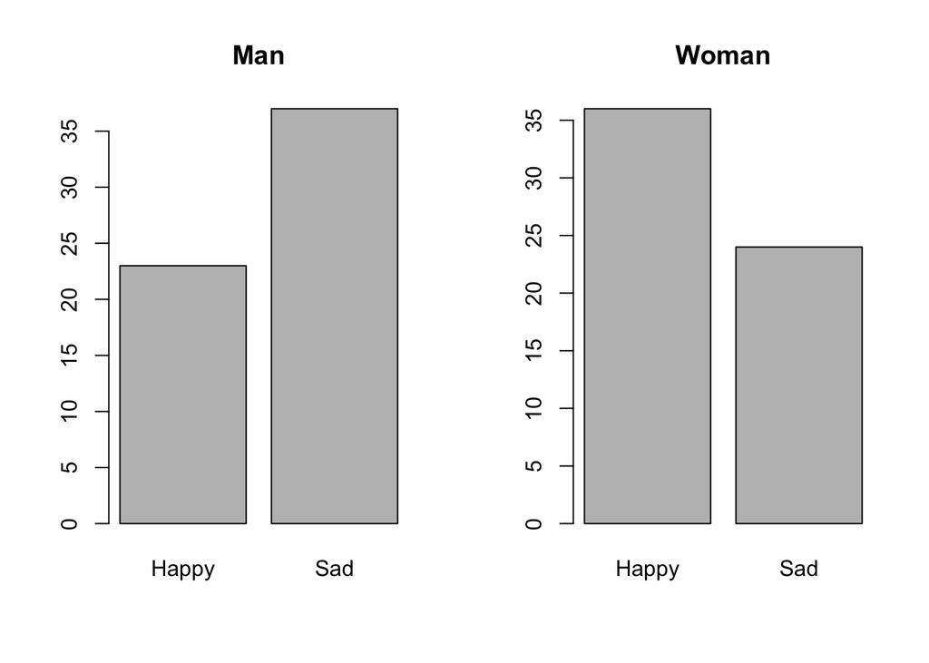

```r
par(mfrow = c(1, 2))
barplot(t[,1], main = "Man")
barplot(t[,2], main = "Woman")
```

### 2.4 Proportions

```r
round(prop.table(t, 1),2)
```

```
##
##          Man Woman
##   Happy 0.39  0.61
##   Sad   0.61  0.39
```

## 3 Parametric test

### 3.1 Conditions

#### 3.1.1 Independent observations

The independence of observations is guaranteed by the recruitment process.

### 3.2 Test

```r
test <- chisq.test(data$mood, data$gender) #ok jamovi
test
```

```
##
##  Pearson's Chi-squared test with Yates' continuity correction
##
## data:  data$mood and data$gender
## X-squared = 4.8013, df = 1, p-value = 0.02844
```

### 3.3 Post-test conditions

#### 3.3.1 More than 5 observations in each combination of theoretical frequencies

```r
all(test$expected > 5)
```

```
## [1] TRUE
```

### 3.4 Effect size (nominal)

#### 3.4.1 Standardized residuals

```r
test$stdres
```

```
##          data$gender
## data$mood       Man     Woman
##     Happy -2.373794  2.373794
##     Sad    2.373794 -2.373794
```

Values greater than 2 indicate over-representation, values less than -2 indicate under-representation.

#### 3.4.2 Odds ratio (2x2 only)

```r
n00 <- t[1,1]
n01 <- t[1,2]
n10 <- t[2,1]
n11 <- t[2,2]
OR <- (n00 * n11)/(n01 * n10)
OR # ok jamovi
```

```
## [1] 0.4144144
```

Ratio of proportions. When there is no effect, the OR is equal to 1. In this case, the two proportions are equal: we have the same number in the numerator and in the denominator.

#### 3.4.3 Relative risk (2x2 only)

```r
if(!require(DescTools)) install.packages("DescTools")
library(DescTools)

RelRisk(t) # ok jamovi
```

```
## [1] 0.6426935
```

#### 3.4.4 Cramer’s V

```r
if(!require(rcompanion)) install.packages("rcompanion")
library(rcompanion)

(cramer <- cramerV(data$mood, data$gender)) #ok jamovi
```

```
## Cramer V
##   0.2167
```

Cramer’s V for tables bigger than 2x2. Effect: .10 low, .30 moderate, .50 high.

### 3.5 Effect size (ordinal)

#### 3.5.1 Gamma

```r
data$gender <- factor(data$gender)
data$mood <- factor(data$mood, levels=c("Happy", "Sad"))

if(!require(DescTools)) install.packages("DescTools")
library(DescTools)

GoodmanKruskalGamma(table(data$mood, data$gender)) # ok jamovi
```

```
## [1] -0.4140127
```

For ordinal variables, the Gamma if parametric. The effect is interpreted as a correlation coefficient, which ranges from -1 to +1. The closer the result is to 0, the less the variables are dependent on each other, and vice versa.

### 3.6 Power analysis

#### 3.6.1 Finding power

```r
if(!require(pwr)) install.packages("pwr")
library(pwr)
pwr.chisq.test(w = cramer, N = length(data$mood), df = test$parameter)
```

```
##
##      Chi squared power calculation
##
##               w = 0.2167
##               N = 120
##              df = 1
##       sig.level = 0.05
##           power = 0.6605211
##
## NOTE: N is the number of observations
```

#### 3.6.2 Finding N

```r
pwr.chisq.test(w = cramer, df = test$parameter, sig.level = 0.05, power = 0.8)
```

```
##
##      Chi squared power calculation
##
##               w = 0.2167
##               N = 167.1432
##              df = 1
##       sig.level = 0.05
##           power = 0.8
##
## NOTE: N is the number of observations
```

## 4 Non-parametric test: Continuity correction

```r
test <- chisq.test(data$mood, data$gender, correct = T) #ok jamovi
test
```

```
##
##  Pearson's Chi-squared test with Yates' continuity correction
##
## data:  data$mood and data$gender
## X-squared = 4.8013, df = 1, p-value = 0.02844
```

Interpretation: continuity p-value from Yates or Fisher’s exact test if theoretical numbers <5. Continuity correction limits the bias brought by the fact that the sampling distribution is discrete but the chi-square distribution is continuous.

### 4.1 Effect size (ordinal)

#### 4.1.1 Kendall Tau B

```r
data$gender <- factor(data$gender)
data$mood <- factor(data$mood, levels=c("Happy", "Sad"))

if(!require(DescTools)) install.packages("DescTools")
library(DescTools)

KendallTauB(table(data$mood, data$gender)) # ok jamovi
```

```
## [1] -0.2166968
```

For ordinal variables, Kendall’s Tau-b if non-parametric. The effect is interpreted as a correlation coefficient, which ranges from -1 to +1. The closer the result is to 0, the less the variables are dependent on each other, and vice versa.

### 4.2 Filter by adding a variable

```r
xtabs(~mood+gender+profil, data)
```

```
## , , profil = Athletic
##
##        gender
## mood    Man Woman
##   Happy   6    11
##   Sad    19     6
##
## , , profil = Dreamer
##
##        gender
## mood    Man Woman
##   Happy   9    13
##   Sad    13     9
##
## , , profil = Scientist
##
##        gender
## mood    Man Woman
##   Happy   8    12
##   Sad     5     9
```

## 5 Non-parametric test: Fisher’s Exact Test

```r
fisher.test(data$mood, data$gender) #ok jamovi
```

```
##
##  Fisher's Exact Test for Count Data
##
## data:  data$mood and data$gender
## p-value = 0.02802
## alternative hypothesis: true odds ratio is not equal to 1
## 95 percent confidence interval:
##  0.1863378 0.9176170
## sample estimates:
## odds ratio
##  0.4175676
```

## 6 Results and recommendations

The chi-square test (with continuity correction) rejects independence between mood and gender in this sample, and the standardized residuals and Cramer’s V above indicate the strength and direction of the association. Report which mood/gender combination is over- or under-represented, and confirm the finding holds under Fisher’s exact test before drawing conclusions.